# laptop_prices_analysis_DA_Project

## import libraries

```python
import pandas as pd
import numpy as py
import matplotlib.pyplot as plt
import seaborn as sns
import warnings
warnings.filterwarnings('ignore')
```

### import data

```python
df=pd.read_csv("laptop_prices_dataset.csv")
```

```python
df.head(3)
```

|  | Company | Product | TypeName | Inches | Ram | OS | Weight | Price_euros | Screen | ScreenW | ... | RetinaDisplay | CPU_company | CPU_freq | CPU_model | PrimaryStorage | SecondaryStorage | PrimaryStorageType | SecondaryStorageType | GPU_company | GPU_model |
| --- | --- | --- | --- | --- | --- | --- | --- | --- | --- | --- | --- | --- | --- | --- | --- | --- | --- | --- | --- | --- | --- |
| 0 | Apple | MacBook Pro | Ultrabook | 13.3 | 8 | macOS | 1.37 | 1339.69 | Standard | 2560 | ... | Yes | Intel | 2.3 | Core i5 | 128 | 0 | SSD | No | Intel | Iris Plus Graphics 640 |
| 1 | Apple | Macbook Air | Ultrabook | 13.3 | 8 | macOS | 1.34 | 898.94 | Standard | 1440 | ... | No | Intel | 1.8 | Core i5 | 128 | 0 | Flash Storage | No | Intel | HD Graphics 6000 |
| 2 | HP | 250 G6 | Notebook | 15.6 | 8 | No OS | 1.86 | 575.00 | Full HD | 1920 | ... | No | Intel | 2.5 | Core i5 7200U | 256 | 0 | SSD | No | Intel | HD Graphics 620 |

3 rows × 23 columns

```python
df.columns.values
```

```
array(['Company', 'Product', 'TypeName', 'Inches', 'Ram', 'OS', 'Weight',
       'Price_euros', 'Screen', 'ScreenW', 'ScreenH', 'Touchscreen',
       'IPSpanel', 'RetinaDisplay', 'CPU_company', 'CPU_freq',
       'CPU_model', 'PrimaryStorage', 'SecondaryStorage',
       'PrimaryStorageType', 'SecondaryStorageType', 'GPU_company',
       'GPU_model'], dtype=object)
```

```python
df.shape
```

```
(1275, 23)
```

## Data Cleaning

```python
df.info()
```

```
<class 'pandas.core.frame.DataFrame'>
RangeIndex: 1275 entries, 0 to 1274
Data columns (total 23 columns):
 #   Column                Non-Null Count  Dtype
---  ------                --------------  -----
 0   Company               1275 non-null   object
 1   Product               1275 non-null   object
 2   TypeName              1275 non-null   object
 3   Inches                1275 non-null   float64
 4   Ram                   1275 non-null   int64
 5   OS                    1275 non-null   object
 6   Weight                1275 non-null   float64
 7   Price_euros           1275 non-null   float64
 8   Screen                1275 non-null   object
 9   ScreenW               1275 non-null   int64
 10  ScreenH               1275 non-null   int64
 11  Touchscreen           1275 non-null   object
 12  IPSpanel              1275 non-null   object
 13  RetinaDisplay         1275 non-null   object
 14  CPU_company           1275 non-null   object
 15  CPU_freq              1275 non-null   float64
 16  CPU_model             1275 non-null   object
 17  PrimaryStorage        1275 non-null   int64
 18  SecondaryStorage      1275 non-null   int64
 19  PrimaryStorageType    1275 non-null   object
 20  SecondaryStorageType  1275 non-null   object
 21  GPU_company           1275 non-null   object
 22  GPU_model             1275 non-null   object
dtypes: float64(4), int64(5), object(14)
memory usage: 229.2+ KB
```

```python
df.isnull().sum()
```

```
Company                 0
Product                 0
TypeName                0
Inches                  0
Ram                     0
OS                      0
Weight                  0
Price_euros             0
Screen                  0
ScreenW                 0
ScreenH                 0
Touchscreen             0
IPSpanel                0
RetinaDisplay           0
CPU_company             0
CPU_freq                0
CPU_model               0
PrimaryStorage          0
SecondaryStorage        0
PrimaryStorageType      0
SecondaryStorageType    0
GPU_company             0
GPU_model               0
dtype: int64
```

```python
df['OS'].unique()
```

```
array(['macOS', 'No OS', 'Windows 10', 'Mac OS X', 'Linux', 'Android',
       'Windows 10 S', 'Chrome OS', 'Windows 7'], dtype=object)
```

```python
df['OS'].nunique()
```

```
9
```

```python
#df.drop(columns=['Unnamed:0'],inplace=True)
#df["Ram"]=df["Ram"].str.replace("GB","")
#df["Weight"]=df["Weight"].str.replace("kg","")
#df["Ram"]=df["Ram"].astype("int")
#df["Weight"]=df["Weight"].astype("float")
```

```python
df.duplicated().sum()
```

```
0
```

```python
df.describe()
```

|  | Inches | Ram | Weight | Price_euros | ScreenW | ScreenH | CPU_freq | PrimaryStorage | SecondaryStorage |
| --- | --- | --- | --- | --- | --- | --- | --- | --- | --- |
| count | 1275.000000 | 1275.000000 | 1275.000000 | 1275.000000 | 1275.000000 | 1275.000000 | 1275.000000 | 1275.000000 | 1275.000000 |
| mean | 15.022902 | 8.440784 | 2.040525 | 1134.969059 | 1900.043922 | 1073.904314 | 2.302980 | 444.517647 | 176.069020 |
| std | 1.429470 | 5.097809 | 0.669196 | 700.752504 | 493.346186 | 283.883940 | 0.503846 | 365.537726 | 415.960655 |
| min | 10.100000 | 2.000000 | 0.690000 | 174.000000 | 1366.000000 | 768.000000 | 0.900000 | 8.000000 | 0.000000 |
| 25% | 14.000000 | 4.000000 | 1.500000 | 609.000000 | 1920.000000 | 1080.000000 | 2.000000 | 256.000000 | 0.000000 |
| 50% | 15.600000 | 8.000000 | 2.040000 | 989.000000 | 1920.000000 | 1080.000000 | 2.500000 | 256.000000 | 0.000000 |
| 75% | 15.600000 | 8.000000 | 2.310000 | 1496.500000 | 1920.000000 | 1080.000000 | 2.700000 | 512.000000 | 0.000000 |
| max | 18.400000 | 64.000000 | 4.700000 | 6099.000000 | 3840.000000 | 2160.000000 | 3.600000 | 2048.000000 | 2048.000000 |

# Data is neat and clean and its ready to EDA & visualization then find the insight inLaptop sales analysis dataset

### Exploratory data analysis by: Univeriate analysis and feature engineering

# column by prices_euros

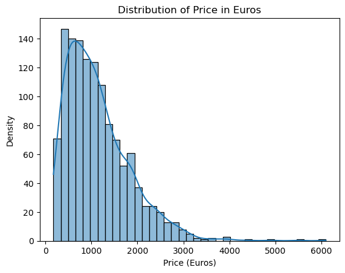

```python
# Create a distribution plot using histplot
y = sns.histplot(df["Price_euros"], kde=True)  # kde=True adds a kernel density estimate
plt.title('Distribution of Price in Euros')
plt.xlabel('Price (Euros)')
plt.ylabel('Density')
plt.show()
```

# The analysis reveals the distribution of prices in euros, highlighting key trends and patterns. This visualization aids in understanding the price range and density, providing valuable insights for decision-making

## Column -> company

```python
df["Company"].value_counts()
```

```
Company
Dell         291
Lenovo       289
HP           268
Asus         152
Acer         101
MSI           54
Toshiba       48
Apple         21
Samsung        9
Razer          7
Mediacom       7
Microsoft      6
Xiaomi         4
Vero           4
Chuwi          3
Google         3
Fujitsu        3
LG             3
Huawei         2
Name: count, dtype: int64
```

```python
df["Company"].value_counts().sum()
```

```
1275
```

# total number of laptop is 1275 in all company

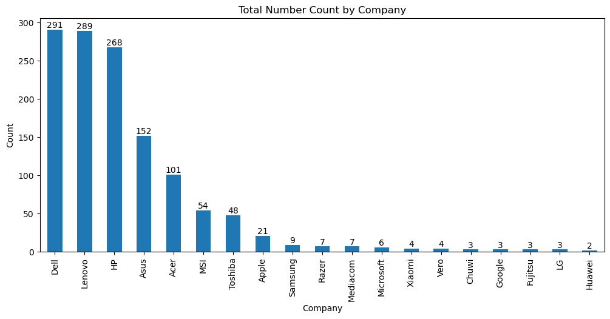

```python
plt.figure(figsize=(12,5))
plt.title('Total Number Count by Company')
y=df['Company'].value_counts().plot(kind='bar')
for bar in y.containers:
    y.bar_label(bar)
plt.xlabel('Company')
plt.ylabel('Count')
```

### Dell, Lenovo, and HP dominate the market, with each having close to 300 units, significantly ahead of other brands.

### Asus and Acer hold mid-tier positions, with 152 and 101 units respectively, showing a notable presence.

### Brands like Apple, Samsung, and Microsoft have relatively low counts, while Huawei has the least representation with just 2 units.

# Column OS

```python
df['OS'].value_counts()
```

```
OS
Windows 10      1048
No OS             66
Linux             58
Windows 7         45
Chrome OS         27
macOS             13
Mac OS X           8
Windows 10 S       8
Android            2
Name: count, dtype: int64
```

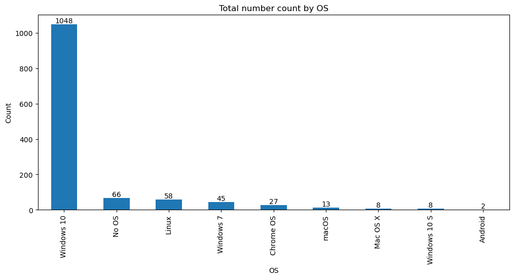

```python
plt.figure(figsize=(12, 5))
plt.title('Total number count by OS')

# Get the value counts of the 'OS' column
os_counts = df['OS'].value_counts()

# Plot the bar chart
bars = os_counts.plot(kind='bar')

# Add labels to the bars
for bar in bars.containers:
    bars.bar_label(bar)

plt.xlabel('OS')
plt.ylabel('Count')
plt.show()
```

## Windows 10 is the dominant OS with 1048 users, vastly outpacing all other operating systems.

## Linux and "No OS" options have moderate adoption, with 58 and 66 users respectively, suggesting some preference for open-source or customizable setups.

## macOS, Windows 10 S, and Android have very low usage, indicating limited adoption in this dataset.

# Column Touchscreen

```python
df['Touchscreen'].value_counts()
```

```
Touchscreen
No     1087
Yes     188
Name: count, dtype: int64
```

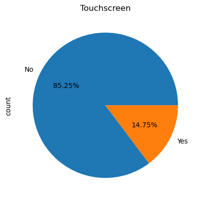

```python
df['Touchscreen'].value_counts().plot(kind='pie', autopct='%.2f%%' ,title='Touchscreen')
```

### ouchscreen laptops are a minority, making up only 14.75% of the total.

### The vast majority (85.25%) of laptops do not have touchscreen functionality, indicating traditional screens remain dominant.

### Touchscreen adoption is relatively low, possibly due to cost, battery concerns, or user preference for non-touch displays.

# Column-> RAM

```python
df['Ram'].value_counts()
```

```
Ram
8     613
4     367
16    198
6      35
12     25
32     17
2      16
24      3
64      1
Name: count, dtype: int64
```

```
<function matplotlib.pyplot.show(close=None, block=None)>
```

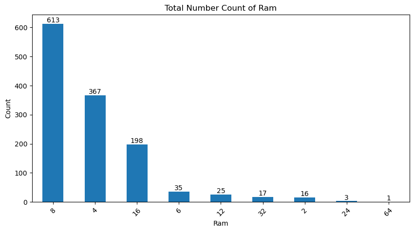

```python
plt.figure(figsize=(10,5))
y=df['Ram'].value_counts().plot(kind='bar')
for bar in y.containers:
    y.bar_label(bar)
plt.title("Total Number Count of Ram")
plt.ylabel("Count")
plt.xticks(rotation=45)
plt.show
```

### 8GB RAM is the most common configuration, with 613 laptops featuring it, followed by 4GB (367) and 16GB (198).

### Lower RAM options like 2GB and 6GB are significantly less common, indicating a shift toward higher memory capacities.

### High-end configurations like 32GB and 64GB are rare, suggesting they are mostly found in premium or specialized device

# Columns GPU_company

```python
df['GPU_company'].value_counts()
```

```
GPU_company
Intel     704
Nvidia    396
AMD       174
ARM         1
Name: count, dtype: int64
```

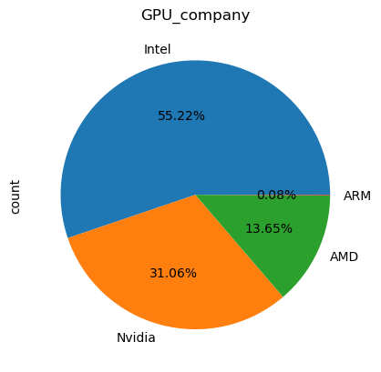

```python
df['GPU_company'].value_counts().plot(kind='pie', autopct='%.2f%%' ,title='GPU_company')
```

### Intel dominates the GPU market with 55.22% share, followed by Nvidia at 31.06%.

### AMD holds a smaller but notable share of 13.65%, making it the third most common GPU provider.

### ARM has an extremely minimal presence (0.08%), indicating its limited use in this dataset.

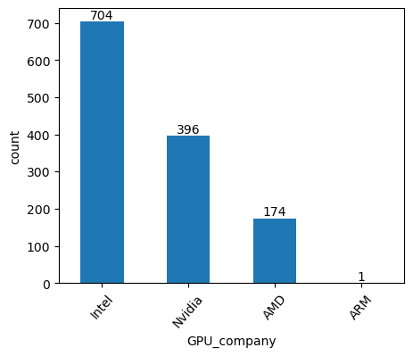

```python
plt.figure(figsize=(5,4))
g=df['GPU_company'].value_counts().plot(kind='bar')
for bar in g.containers:
    g.bar_label(bar)

plt.ylabel("count")
plt.xlabel("GPU_company")
plt.xticks(rotation=49)
plt.show()
```

### Intel leads the GPU market with 704 units, followed by Nvidia (396) and AMD (174).

### Nvidia holds a strong second position, indicating its significant presence in the discrete GPU segment.

### ARM has a negligible share with just one unit, suggesting minimal representation in this dataset

# Column -> CPU_company

```python
df['CPU_company'].value_counts()
```

```
CPU_company
Intel      1214
AMD          60
Samsung       1
Name: count, dtype: int64
```

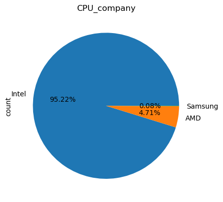

```python
df['CPU_company'].value_counts().plot(kind='pie',autopct='%.2f%%' ,title='CPU_company')
```

### Intel dominates the market with 95.22% share, making it the overwhelmingly preferred processor brand.

### AMD (4.71%) and Samsung (0.08%) have minimal presence, indicating limited competition in this dataset.

# Column IPSpanel

```python
df['IPSpanel'].value_counts()
```

```
IPSpanel
No     918
Yes    357
Name: count, dtype: int64
```

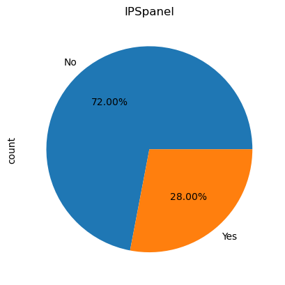

```python
df['IPSpanel'].value_counts().plot(kind='pie',autopct='%.2f%%' ,title='IPSpanel')
```

# Column Inches

```python
df['Inches'].value_counts()
```

```
Inches
15.6    647
14.0    193
17.3    164
13.3    160
12.5     39
11.6     31
12.0      6
13.5      6
13.9      6
12.3      5
10.1      4
15.4      4
15.0      4
13.0      2
18.4      1
17.0      1
14.1      1
11.3      1
Name: count, dtype: int64
```

```python
#a=sns.countplot(x='Inches',data=df)
#for bar in a.containers:
   # a.bar_label(bar )
```

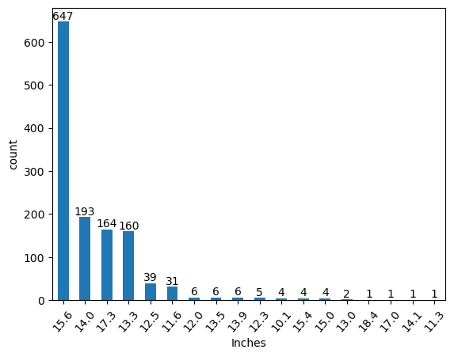

```python
# Plot the value counts of the 'Inches' column
a = df['Inches'].value_counts().plot(kind='bar')

# Add labels to each bar
for container in a.containers:
    a.bar_label(container)
plt.ylabel("count")
plt.xlabel("Inches")
plt.xticks(rotation=49)


# Show the plot
plt.show()
```

### The 15.6-inch screen size is the most common, with 647 units, indicating it as the preferred choice for most users.

### 14.0-inch and 17.3-inch screens follow, with 193 and 164 units, respectively, showing moderate popularity.

# Column PrimaryStorageType

```python
y=df['PrimaryStorageType'].value_counts()
y
```

```
PrimaryStorageType
SSD              837
HDD              359
Flash Storage     71
Hybrid             8
Name: count, dtype: int64
```

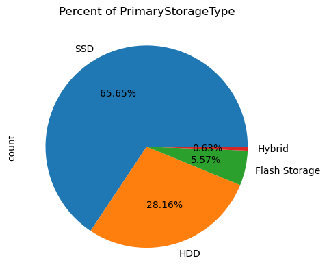

```python
y=df['PrimaryStorageType'].value_counts().plot(kind = 'pie' ,
autopct = '%.2f%%', title='Percent of PrimaryStorageType')
```

### SSD is the dominant primary storage type (65.65%), followed by HDD (28.16%), indicating a preference for faster storage solutions.

### Hybrid (0.63%) and Flash Storage (5.57%) have minimal market share, suggesting they are niche choices compared to SSD and HDD.

# Column Screen

```python
x=df['Screen'].value_counts()
x
```

```
Screen
Full HD        835
Standard       369
4K Ultra HD     43
Quad HD+        28
Name: count, dtype: int64
```

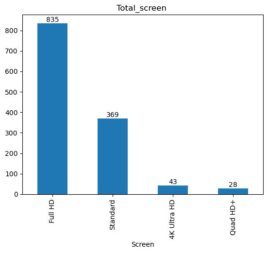

```python
x=df['Screen'].value_counts().plot(kind='bar')
plt.title('Total_screen ')
plt.figure(figsize=(12,4))
for bars in x.containers:
    x.bar_label(bars)
plt.show()
```

### Full HD screens dominate the market (835 units), significantly outnumbering other screen types, indicating a strong preference for this resolution.

### Higher-resolution screens like 4K Ultra HD (43) and Quad HD+ (28) have much lower adoption, suggesting they are premium or niche choices.

# Column SecondarystorageType

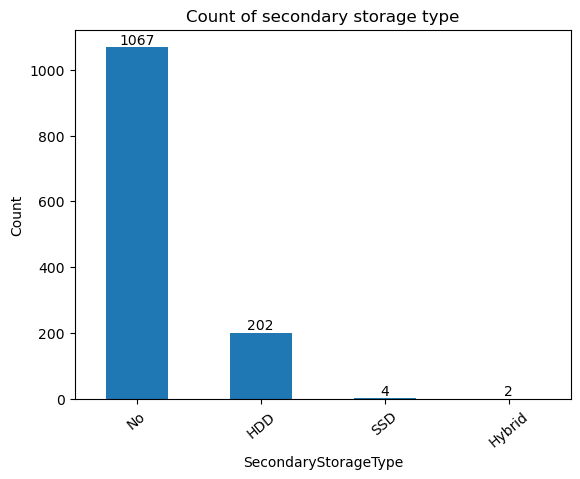

```python
t=df['SecondaryStorageType'].value_counts().plot(kind='bar',title='Count of secondary storage type')
for bar in t.containers:
    t.bar_label(bar)
plt.ylabel("Count")
plt.xticks(rotation=40)
plt.show()
```

### The majority of devices (1067) do not have secondary storage, indicating a preference for single-storage configurations.

### HDD is the most common secondary storage option (202 units), while SSD (4) and Hybrid (2) are rarely used.

# Product column

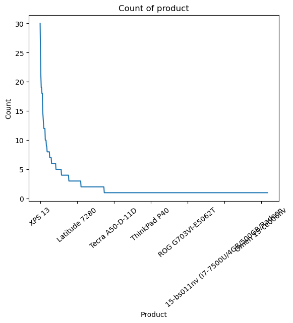

```python
t=df['Product'].value_counts().plot(kind='line',title='Count of product')
for bar in t.containers:
    t.line_label(line)
plt.ylabel("Count")
plt.xticks(rotation=40)
plt.show()
```

### he XPS 13 is the most common laptop model, with significantly higher availability compared to other models.

### The distribution follows a steep drop-off, indicating that only a few models dominate the market while many others have low availability.

# -> Subplot of 'Ram', 'OS', 'Touchscreen', 'IPSpanel', 'RetinaDisplay', 'CPU_company

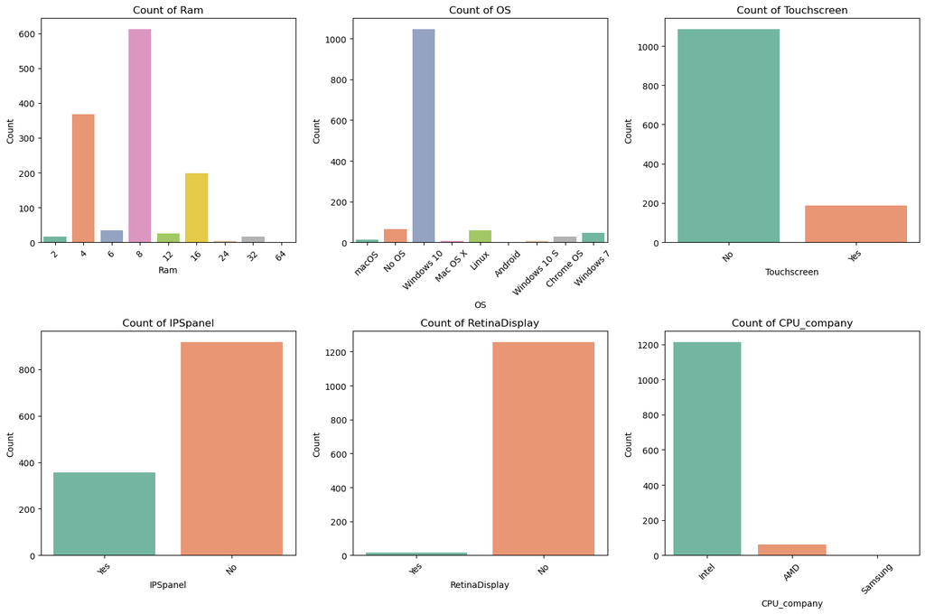

```python
# Define the categorical columns to plot
columns_to_plot = ['Ram', 'OS', 'Touchscreen', 'IPSpanel', 'RetinaDisplay', 'CPU_company']

# Set up subplots
fig, axes = plt.subplots(nrows=2, ncols=3, figsize=(15, 10))  # Adjust rows and columns as needed
axes = axes.flatten()  # Flatten for easy iteration

# Create countplots for each categorical column
for i, col in enumerate(columns_to_plot):
    sns.countplot(x=df[col], ax=axes[i], palette="Set2")
    axes[i].set_title(f"Count of {col}")
    axes[i].set_ylabel("Count")
    axes[i].set_xticklabels(axes[i].get_xticklabels(), rotation=45)

# Adjust layout
plt.tight_layout()
plt.show()
```

### The most common RAM size is 8GB, followed by 4GB and 16GB, while higher capacities like 32GB and 64GB are rare.

### Windows 10 dominates the OS category, with very few devices running other operating systems.

### Touchscreen laptops are significantly fewer, making up a small portion of the total.

### Intel CPUs are overwhelmingly dominant, with AMD and Samsung having a minimal presence.

### Most devices lack IPS panels and Retina displays, indicating a preference for standard screen technology.